# Modelling TB Transmission Dynamics in Kenya (2000–2022)

Author

Fiona Huini

Published

May 10, 2026

## Background

Tuberculosis (TB) remains a leading cause of infectious disease mortality globally, with Kenya classified among the 30 high TB burden countries by the World Health Organization (WHO). In 2022, Kenya reported an estimated incidence of 268 cases per 100,000 population, with treatment success rates of approximately 87% [@who2023].

A key feature of TB epidemiology is the long latent period between initial infection and progression to active disease. Only 5–10% of latently infected individuals develop active TB in their lifetime, with risk elevated by HIV co-infection, malnutrition, and immunosuppression [@pai2016]. This latent dynamic makes TB fundamentally different from directly transmitted diseases and requires explicit compartmental representation in transmission models.

Kenya’s national TB program operates under the **End TB Strategy**, targeting a 90% reduction in TB deaths and 80% reduction in incidence by 2030 relative to 2015 baselines. Achieving these targets requires understanding the drivers of transmission and projecting the impact of intervention scale-up.

Here, we have developed a deterministic compartmental model with five states: Susceptible (**S**), Latent (**E**), Infectious (**I**), On Treatment (**T**), and Recovered (**R**). The model accounts for TB’s characteristically long latent period and the possibility of relapse following recovery.

### Baseline Simulation

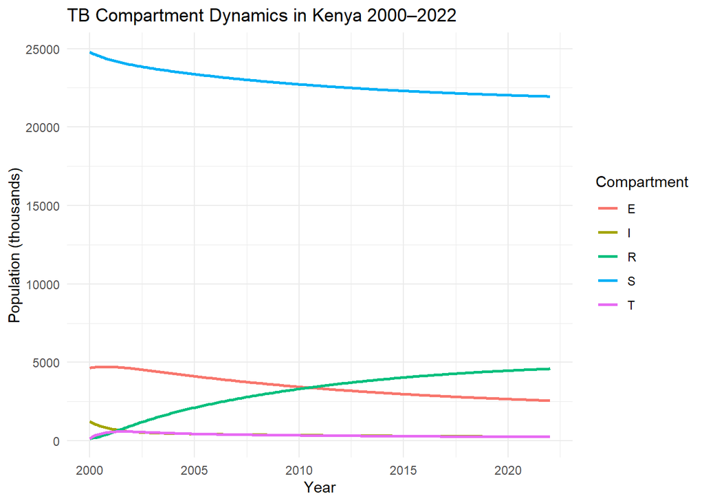

Figure 1: Baseline TB compartment dynamics in Kenya (2000–2022)

```r
source("R/model.R")
library(ggplot2)

# Parameters — literature values
params <- c(
  beta    = 0.8,
  k       = 0.1,
  mu      = 0.016,
  tau     = 0.8,
  delta   = 0.15,
  gamma_r = 0.85,
  rho     = 0.02
)

N0 <- 31000000

initial_state <- c(
  S = N0 * 0.80,
  E = N0 * 0.15,
  I = N0 * 0.04,
  T = N0 * 0.005,
  R = N0 * 0.005
)

times <- seq(0, 22, by = 0.1)

result <- run_tb_model(params, initial_state, times)

library(tidyverse)
result |>
  pivot_longer(-time, names_to = "Compartment", values_to = "Count") |>
  ggplot(aes(x = time + 2000, y = Count / 1000, color = Compartment)) +
  geom_line(linewidth = 0.9) +
  labs(
    x = "Year",
    y = "Population (thousands)",
    title = "TB Compartment Dynamics in Kenya 2000–2022",
    color = "Compartment"
  ) +
  theme_minimal()
```